# Draft

Group 313:2

19/11/2019

## Introduction

YouTube is an American video-sharing platform that maintains a list of the top trending videos on the platform daily. YouTube uses a combination of factors including measuring user interactions (number of views, shares, comments, and likes). So using these interactions our primary goal is to analyze what factors affect how popular a YouTube video will be and if anyone desires to upload a Youtube video what factors can affect it to reach it’s maximum so more people can view that video and gain more personal benefit from advertisement revenue. And statistical analysis over time which could also help in managing videos over a period of time. The whole project is hosted on github here you can find all the project related files https://github.com/jangidkrishna/stat240_final_project.

## Background

We found our data set on kaggle https://www.kaggle.com/datasnaek/youtube-new. And since all the category tags were in a json to convert those we wrote another script **(convert.rmd)** to merge those jsons with respective category ids. We have data for 8 countries ( USA, Great Britain, Canada, France, Russia, Mexico, Japan, and India) about top trending videos over 205 days in CSV and we have categories id referenced in JSON. There are 16 columns:

- video_id: contains a unique id of the video (string)
- trending_date: the date when this video was trending. (date)
- title: title of that video (string)
- channel_title: the channel name from where it was published (string)
- category_id: id of category reference from JSON (number)
- publish_time: time video was published (date)
- tags: tags for the video (string)
- views: # of views on that video (number)
- likes: # of likes on that video (number)
- dislikes: # of dislikes on that video (number)
- comment_count: #of comments on that video (number)
- thumbnail_link: thumbnail link of that video (string)
- comments_disabled: are comments disabled on that video (bool)
- ratings_disabled: are ratings disabled on that video (bool)
- video_error_or_removed: is videos removed or there is an error (bool)
- description: description of that videos (string)

## Analysis

### 1

> Which categories have the most likes?
- Filter the data set to only include category, view, likes, dislikes, and comments (if any). -Determine which categories have the most likes by summing up the number of likes between each category and arranging them by number of likes

```r
##Canada
can = ca_data %>%
  select(channel_title, category_title, views, likes, dislikes, comment_count) %>%
  drop_na() %>%
  dplyr::group_by(category_title) %>%
  dplyr::summarize(likes = sum(likes)) %>%
  arrange(desc(likes)) %>%
  top_n(n=10) %>%
  print()
```

```
## # A tibble: 10 x 2
##    category_title           likes
##    <chr>                    <dbl>
##  1 Music                564447530
##  2 Entertainment        387245433
##  3 Comedy               196046674
##  4 People & Blogs       105388564
##  5 Film & Animation      77802003
##  6 Sports                59449419
##  7 Gaming                51726552
##  8 Howto & Style         51183104
##  9 Science & Technology  42814598
## 10 News & Politics       32705054
```

```r
##US
usa = us_data %>%
    select(channel_title, category_title, views, likes, dislikes, comment_count) %>%
  drop_na() %>%
  group_by(category_title) %>%
  summarize(likes = sum(likes)) %>%
  arrange(desc(likes)) %>%
  top_n(n=10) %>%
  print()
```

```
## # A tibble: 10 x 2
##    category_title            likes
##    <chr>                     <dbl>
##  1 Music                1416838584
##  2 Entertainment         530516491
##  3 Comedy                216346746
##  4 People & Blogs        186615999
##  5 Film & Animation      165997476
##  6 Howto & Style         162880075
##  7 Sports                 98621211
##  8 Science & Technology   82532638
##  9 Gaming                 69038284
## 10 Education              49257772
```

```r
##France
fra = fr_data %>%
    select(channel_title, category_title, views, likes, dislikes, comment_count) %>%
  drop_na() %>%
  group_by(category_title) %>%
  summarize(likes = sum(likes)) %>%
  arrange(desc(likes)) %>%
  top_n(n=10)%>%
  print()
```

```
## # A tibble: 10 x 2
##    category_title           likes
##    <chr>                    <dbl>
##  1 Music                277314234
##  2 Comedy               130805444
##  3 Entertainment        118243560
##  4 Sports                43964560
##  5 People & Blogs        28927705
##  6 Film & Animation      24631422
##  7 Gaming                22502704
##  8 Science & Technology  18513625
##  9 Howto & Style         15519633
## 10 News & Politics        9301486
```

```r
## Mexico
mxo = mx_data %>%
    select(channel_title, category_title, views, likes, dislikes, comment_count) %>%
  drop_na() %>%
  group_by(category_title) %>%
  summarize(likes = sum(likes)) %>%
  arrange(desc(likes)) %>%
  top_n(n=10)%>%
  print()
```

```
## # A tibble: 10 x 2
##    category_title           likes
##    <chr>                    <dbl>
##  1 Music                227013300
##  2 Entertainment        186692595
##  3 Comedy                55273506
##  4 People & Blogs        47859054
##  5 Sports                30866251
##  6 Howto & Style         24651100
##  7 Gaming                24002503
##  8 Film & Animation      17915248
##  9 News & Politics       11910414
## 10 Science & Technology   5114569
```

```r
##Great Britain
gbn = gb_data %>%
    select(channel_title, category_title, views, likes, dislikes, comment_count) %>%
  drop_na() %>%
  group_by(category_title) %>%
  summarize(likes = sum(likes)) %>%
  arrange(desc(likes)) %>%
  top_n(n=10)%>%
  print()
```

```
## # A tibble: 10 x 2
##    category_title            likes
##    <chr>                     <dbl>
##  1 Music                3742993052
##  2 Entertainment         744266231
##  3 Film & Animation      147418633
##  4 Comedy                143372176
##  5 People & Blogs        135396249
##  6 Sports                 74888487
##  7 Gaming                 70125588
##  8 Howto & Style          51360345
##  9 Science & Technology   31873124
## 10 News & Politics        30651565
```

```r
##India
ind = in_data %>%
    select(channel_title, category_title, views, likes, dislikes, comment_count) %>%
  drop_na() %>%
  group_by(category_title) %>%
  summarize(likes = sum(likes)) %>%
  arrange(desc(likes)) %>%
  top_n(n=10)%>%
  print()
```

```
## # A tibble: 10 x 2
##    category_title           likes
##    <chr>                    <dbl>
##  1 Entertainment        396146637
##  2 Music                254328536
##  3 Comedy               174114686
##  4 Film & Animation      69241553
##  5 Sports                32969986
##  6 People & Blogs        23194729
##  7 Science & Technology  21395585
##  8 News & Politics       15545971
##  9 Howto & Style          7889210
## 10 Education              7471726
```

```r
## Japan
jpn = jp_data %>%
  select(channel_title, category_title, views, likes, dislikes, comment_count) %>%
  drop_na() %>%
  group_by(category_title) %>%
  summarize(likes = sum(likes)) %>%
  arrange(desc(likes)) %>%
  top_n(n=10)%>%
  print()
```

```
## # A tibble: 10 x 2
##    category_title          likes
##    <chr>                   <dbl>
##  1 Music                83596720
##  2 Entertainment        39741269
##  3 People & Blogs        9696311
##  4 Comedy                7547588
##  5 Film & Animation      5920614
##  6 Sports                5563412
##  7 Science & Technology  3784549
##  8 Gaming                3037608
##  9 Howto & Style         2430554
## 10 News & Politics       1659888
```

```r
## Russia
rus = ru_data %>%
    select(channel_title, category_title, views, likes, dislikes, comment_count) %>%
  drop_na() %>%
  group_by(category_title) %>%
  summarize(likes = sum(likes)) %>%
  arrange(desc(likes)) %>%
  top_n(n=10)%>%
  print()
```

```
## # A tibble: 10 x 2
##    category_title           likes
##    <chr>                    <dbl>
##  1 Music                120129951
##  2 Entertainment         98904908
##  3 People & Blogs        73222107
##  4 Comedy                69987601
##  5 Science & Technology  25866814
##  6 Autos & Vehicles      21223727
##  7 Film & Animation      19150169
##  8 News & Politics       15274142
##  9 Howto & Style         12708499
## 10 Gaming                12541307
```

### 2

> Which categories have the most comments?

-Repeat number 1 with comments

```r
##Canada
can1 = ca_data %>%
  select(channel_title, category_title, views, likes, dislikes, comment_count) %>%
  drop_na() %>%
  group_by(category_title) %>%
  summarize(comment_count = sum(comment_count)) %>%
  arrange(desc(comment_count)) %>%
  top_n(n=10)%>%
  print()
```

```
## # A tibble: 10 x 2
##    category_title       comment_count
##    <chr>                        <dbl>
##  1 Entertainment             55313036
##  2 Music                     52435252
##  3 Comedy                    19638776
##  4 People & Blogs            16818201
##  5 Film & Animation          10086573
##  6 Gaming                     9664887
##  7 News & Politics            9259788
##  8 Howto & Style              8342917
##  9 Sports                     7661342
## 10 Science & Technology       7209219
```

```r
##US
usa1 = us_data %>%
    select(channel_title, category_title, views, likes, dislikes, comment_count) %>%
  drop_na() %>%
  group_by(category_title) %>%
  summarize(comment_count = sum(comment_count)) %>%
  arrange(desc(comment_count)) %>%
  top_n(n=10)%>%
  print()
```

```
## # A tibble: 10 x 2
##    category_title       comment_count
##    <chr>                        <dbl>
##  1 Music                    125296396
##  2 Entertainment             73566498
##  3 People & Blogs            24778032
##  4 Howto & Style             23149550
##  5 Comedy                    22545582
##  6 Film & Animation          17887060
##  7 Gaming                    14740713
##  8 Science & Technology      11989926
##  9 Sports                    11192155
## 10 News & Politics            6039433
```

```r
##France
fra1 = fr_data %>%
    select(channel_title, category_title, views, likes, dislikes, comment_count) %>%
  drop_na() %>%
  group_by(category_title) %>%
  summarize(comment_count = sum(comment_count)) %>%
  arrange(desc(comment_count)) %>%
  top_n(n=10)%>%
  print()
```

```
## # A tibble: 10 x 2
##    category_title       comment_count
##    <chr>                        <dbl>
##  1 Music                     25446289
##  2 Entertainment             15729924
##  3 Comedy                     9136814
##  4 Sports                     4575418
##  5 People & Blogs             4104818
##  6 Gaming                     3047593
##  7 Science & Technology       2926363
##  8 Film & Animation           2841655
##  9 News & Politics            1896101
## 10 Howto & Style              1759358
```

```r
## Mexico
mxo1 = mx_data %>%
    select(channel_title, category_title, views, likes, dislikes, comment_count) %>%
  drop_na() %>%
  group_by(category_title) %>%
  summarize(comment_count = sum(comment_count)) %>%
  arrange(desc(comment_count)) %>%
  top_n(n=10)%>%
  print()
```

```
## # A tibble: 10 x 2
##    category_title       comment_count
##    <chr>                        <dbl>
##  1 Entertainment             29688886
##  2 Music                     21744565
##  3 People & Blogs             7304854
##  4 Comedy                     6838587
##  5 Howto & Style              3682138
##  6 Sports                     3206096
##  7 Gaming                     2887305
##  8 News & Politics            2328675
##  9 Film & Animation           2048173
## 10 Science & Technology        881509
```

```r
##Great Britain
gbn1 = gb_data %>%
    select(channel_title, category_title, views, likes, dislikes, comment_count) %>%
  drop_na() %>%
  group_by(category_title) %>%
  summarize(comment_count = sum(comment_count)) %>%
  arrange(desc(comment_count)) %>%
  top_n(n=10)%>%
  print()
```

```
## # A tibble: 10 x 2
##    category_title       comment_count
##    <chr>                        <dbl>
##  1 Music                    293013140
##  2 Entertainment            116897440
##  3 People & Blogs            18713149
##  4 Comedy                    16718816
##  5 Film & Animation          15590011
##  6 Sports                    10056226
##  7 News & Politics            9386604
##  8 Howto & Style              7356296
##  9 Gaming                     6166994
## 10 Science & Technology       4029065
```

```r
##India
ind1 = in_data %>%
    select(channel_title, category_title, views, likes, dislikes, comment_count) %>%
  drop_na() %>%
  group_by(category_title) %>%
  summarize(comment_count = sum(comment_count)) %>%
  arrange(desc(comment_count)) %>%
  top_n(n=10)%>%
  print()
```

```
## # A tibble: 10 x 2
##    category_title       comment_count
##    <chr>                        <dbl>
##  1 Entertainment             42199473
##  2 Music                     17595070
##  3 Comedy                    13806968
##  4 Science & Technology       9664392
##  5 Film & Animation           5789446
##  6 News & Politics            2954198
##  7 Sports                     2717679
##  8 People & Blogs             2661920
##  9 Education                   943667
## 10 Howto & Style               748899
```

```r
## Japan
jpn1 = jp_data %>%
  select(channel_title, category_title, views, likes, dislikes, comment_count) %>%
  drop_na() %>%
  group_by(category_title) %>%
  summarize(comment_count = sum(comment_count)) %>%
  arrange(desc(comment_count)) %>%
  top_n(n=10)%>%
  print()
```

```
## # A tibble: 10 x 2
##    category_title       comment_count
##    <chr>                        <dbl>
##  1 Music                     11129839
##  2 Entertainment              6052118
##  3 People & Blogs             1669164
##  4 Comedy                     1229425
##  5 Sports                     1051743
##  6 Film & Animation            881008
##  7 Science & Technology        629683
##  8 Gaming                      615833
##  9 News & Politics             542638
## 10 Howto & Style               367734
```

```r
## Russia
rus1 = ru_data %>%
    select(channel_title, category_title, views, likes, dislikes, comment_count) %>%
  drop_na() %>%
  group_by(category_title) %>%
  summarize(comment_count = sum(comment_count)) %>%
  arrange(desc(comment_count)) %>%
  top_n(n=10)%>%
  print()
```

```
## # A tibble: 10 x 2
##    category_title       comment_count
##    <chr>                        <dbl>
##  1 Entertainment             14324340
##  2 Music                     13197717
##  3 People & Blogs            11694645
##  4 Comedy                     8269629
##  5 Science & Technology       5700658
##  6 News & Politics            4724537
##  7 Autos & Vehicles           2245794
##  8 Film & Animation           2138455
##  9 Gaming                     1623861
## 10 Howto & Style              1613128
```

Similar the the earlier question, Music and Entertainment have a consistent presence in the top 3 categories. People & Blogs is also a common category in the top 3. This is most likely due to the more interactive relationship between the youtubers and their audience in this category.

### 3

```r
##Canada
can1 = ca_data %>%
  select(channel_title, category_title, views, likes, dislikes, comment_count) %>%
  drop_na() %>%
  group_by(category_title) %>%
  summarize(comment_count = sum(comment_count)) %>%
  arrange(desc(comment_count)) %>%
  top_n(n=10)%>%
  print()
```

```
## # A tibble: 10 x 2
##    category_title       comment_count
##    <chr>                        <dbl>
##  1 Entertainment             55313036
##  2 Music                     52435252
##  3 Comedy                    19638776
##  4 People & Blogs            16818201
##  5 Film & Animation          10086573
##  6 Gaming                     9664887
##  7 News & Politics            9259788
##  8 Howto & Style              8342917
##  9 Sports                     7661342
## 10 Science & Technology       7209219
```

```r
##US
usa1 = us_data %>%
    select(channel_title, category_title, views, likes, dislikes, comment_count) %>%
  drop_na() %>%
  group_by(category_title) %>%
  summarize(comment_count = sum(comment_count)) %>%
  arrange(desc(comment_count)) %>%
  top_n(n=10)%>%
  print()
```

```
## # A tibble: 10 x 2
##    category_title       comment_count
##    <chr>                        <dbl>
##  1 Music                    125296396
##  2 Entertainment             73566498
##  3 People & Blogs            24778032
##  4 Howto & Style             23149550
##  5 Comedy                    22545582
##  6 Film & Animation          17887060
##  7 Gaming                    14740713
##  8 Science & Technology      11989926
##  9 Sports                    11192155
## 10 News & Politics            6039433
```

```r
##France
fra1 = fr_data %>%
    select(channel_title, category_title, views, likes, dislikes, comment_count) %>%
  drop_na() %>%
  group_by(category_title) %>%
  summarize(comment_count = sum(comment_count)) %>%
  arrange(desc(comment_count)) %>%
  top_n(n=10)%>%
  print()
```

```
## # A tibble: 10 x 2
##    category_title       comment_count
##    <chr>                        <dbl>
##  1 Music                     25446289
##  2 Entertainment             15729924
##  3 Comedy                     9136814
##  4 Sports                     4575418
##  5 People & Blogs             4104818
##  6 Gaming                     3047593
##  7 Science & Technology       2926363
##  8 Film & Animation           2841655
##  9 News & Politics            1896101
## 10 Howto & Style              1759358
```

```r
## Mexico
mxo1 = mx_data %>%
    select(channel_title, category_title, views, likes, dislikes, comment_count) %>%
  drop_na() %>%
  group_by(category_title) %>%
  summarize(comment_count = sum(comment_count)) %>%
  arrange(desc(comment_count)) %>%
  top_n(n=10)%>%
  print()
```

```
## # A tibble: 10 x 2
##    category_title       comment_count
##    <chr>                        <dbl>
##  1 Entertainment             29688886
##  2 Music                     21744565
##  3 People & Blogs             7304854
##  4 Comedy                     6838587
##  5 Howto & Style              3682138
##  6 Sports                     3206096
##  7 Gaming                     2887305
##  8 News & Politics            2328675
##  9 Film & Animation           2048173
## 10 Science & Technology        881509
```

```r
##Great Britain
gbn1 = gb_data %>%
    select(channel_title, category_title, views, likes, dislikes, comment_count) %>%
  drop_na() %>%
  group_by(category_title) %>%
  summarize(comment_count = sum(comment_count)) %>%
  arrange(desc(comment_count)) %>%
  top_n(n=10)%>%
  print()
```

```
## # A tibble: 10 x 2
##    category_title       comment_count
##    <chr>                        <dbl>
##  1 Music                    293013140
##  2 Entertainment            116897440
##  3 People & Blogs            18713149
##  4 Comedy                    16718816
##  5 Film & Animation          15590011
##  6 Sports                    10056226
##  7 News & Politics            9386604
##  8 Howto & Style              7356296
##  9 Gaming                     6166994
## 10 Science & Technology       4029065
```

```r
##India
ind1 = in_data %>%
    select(channel_title, category_title, views, likes, dislikes, comment_count) %>%
  drop_na() %>%
  group_by(category_title) %>%
  summarize(comment_count = sum(comment_count)) %>%
  arrange(desc(comment_count)) %>%
  top_n(n=10)%>%
  print()
```

```
## # A tibble: 10 x 2
##    category_title       comment_count
##    <chr>                        <dbl>
##  1 Entertainment             42199473
##  2 Music                     17595070
##  3 Comedy                    13806968
##  4 Science & Technology       9664392
##  5 Film & Animation           5789446
##  6 News & Politics            2954198
##  7 Sports                     2717679
##  8 People & Blogs             2661920
##  9 Education                   943667
## 10 Howto & Style               748899
```

```r
## Japan
jpn1 = jp_data %>%
  select(channel_title, category_title, views, likes, dislikes, comment_count) %>%
  drop_na() %>%
  group_by(category_title) %>%
  summarize(comment_count = sum(comment_count)) %>%
  arrange(desc(comment_count)) %>%
  top_n(n=10)%>%
  print()
```

```
## # A tibble: 10 x 2
##    category_title       comment_count
##    <chr>                        <dbl>
##  1 Music                     11129839
##  2 Entertainment              6052118
##  3 People & Blogs             1669164
##  4 Comedy                     1229425
##  5 Sports                     1051743
##  6 Film & Animation            881008
##  7 Science & Technology        629683
##  8 Gaming                      615833
##  9 News & Politics             542638
## 10 Howto & Style               367734
```

```r
## Russia
rus1 = ru_data %>%
    select(channel_title, category_title, views, likes, dislikes, comment_count) %>%
  drop_na() %>%
  group_by(category_title) %>%
  summarize(comment_count = sum(comment_count)) %>%
  arrange(desc(comment_count)) %>%
  top_n(n=10)%>%
  print()
```

```
## # A tibble: 10 x 2
##    category_title       comment_count
##    <chr>                        <dbl>
##  1 Entertainment             14324340
##  2 Music                     13197717
##  3 People & Blogs            11694645
##  4 Comedy                     8269629
##  5 Science & Technology       5700658
##  6 News & Politics            4724537
##  7 Autos & Vehicles           2245794
##  8 Film & Animation           2138455
##  9 Gaming                     1623861
## 10 Howto & Style              1613128
```

### Clickbait

```r
# things that could get caught by clickbait unfairly
deceptive = "BREAKING|CONAN|SPOILERS|IFC Films|RIVERDALE|PRESHOW|WIRED"

clickbait_parse = function(df){
  df = df %>%
    mutate(clickbait = case_when(
      str_detect(title, deceptive) ~ FALSE,
      str_detect(title, "^\\d+$") ~ FALSE,
      str_detect(title, "^[^a-z]+$") ~ TRUE,
      str_detect(title, "[A-Z\\s!]{8,}") ~ TRUE,
      str_detect(title, "\\? ?!") ~ TRUE,
      str_detect(title, "! ?\\?") ~ TRUE,
      TRUE ~ FALSE
    ))
  return(df)
}

set.seed(31437)
x = sample_n(US, 250) %>%
  select(title)

x = clickbait_parse(x)

# may have to figure out other languages later
US = clickbait_parse(US)
FR = clickbait_parse(FR)
GB = clickbait_parse(GB)
CA = clickbait_parse(CA)
MX = clickbait_parse(MX)
```

### 4

> How prevalent is clickbait? How do the average number of views vary?

```r
clickbait_sum = function(data){
  df = data %>%
  dplyr::group_by(clickbait) %>%
  dplyr::summarize(n = n(),
            total_views = sum(views),
            average_views = mean(views)) %>%
  mutate(percent = n / sum(n))

  return(df)
}

bind_clickbait_sums = function(){
  US_cbsum = clickbait_sum(US) %>%
   mutate(country = "USA")

  FR_cbsum = clickbait_sum(FR) %>%
    mutate(country = "France")

  GB_cbsum = clickbait_sum(GB) %>%
    mutate(country = "Great Britain")

  MX_cbsum = clickbait_sum(MX) %>%
    mutate(country = "Mexico")

  CA_cbsum = clickbait_sum(CA) %>%
    mutate(country = "Canada")

  clickbait_sums = bind_rows(US_cbsum, FR_cbsum, GB_cbsum, MX_cbsum, CA_cbsum)

  return(clickbait_sums)
}

clickbait_sums = bind_clickbait_sums() %>%
  select(country, everything())
clickbait_sums
```

```
## # A tibble: 10 x 6
##    country       clickbait     n  total_views average_views percent
##    <chr>         <lgl>     <int>        <dbl>         <dbl>   <dbl>
##  1 USA           FALSE     32596  80939889704      2483123.   0.807
##  2 USA           TRUE       7775  14791744748      1902475.   0.193
##  3 France        FALSE     21567  11795896753       546942.   0.572
##  4 France        TRUE      16134   4797605493       297360.   0.428
##  5 Great Britain FALSE     30575 204103753458      6675511.   0.799
##  6 Great Britain TRUE       7684  24310529276      3163786.   0.201
##  7 Mexico        FALSE     21622   9342825437       432098.   0.599
##  8 Mexico        TRUE      14463   3963879831       274070.   0.401
##  9 Canada        FALSE     28660  36068708375      1258503.   0.725
## 10 Canada        TRUE      10855  10101277527       930564.   0.275
```

Clickbait seems to be the more prevalent in France and Mexico (about 40% of trending videos are clickbait) and less prevalent in the US and Great Britain (about 20% of trending videos are clickbait).

### 5

> How well do people receive clickbait?

#### Hypothesis Tests for difference in likes and dislikes per view (separate)

$$H_0: p_C = p_N \\
H_A: p_C \neq p_N$$

```r
LV_test = function(data, type = "clickbait"){
  df = clickbait_parse(data)

  cb_LV = df %>%
    dplyr::group_by(clickbait) %>%
    dplyr::summarize(n = n(),
              p_LV = sum(likes) / sum(views))

  comm_LV = df %>%
    dplyr::group_by(comments_disabled) %>%
    dplyr::summarize(n = n(),
              p_LV = sum(likes) / sum(views))

  if(type == "comments") {
    use = comm_LV
  } else{
    use = cb_LV
  }

  # values for clickbait vids (or comments disabled vids)
  p1 = use$p_LV[2]
  n1 = use$n[2]
  # values for non-clickbait vids (or comments enabled vids)
  p2 = use$p_LV[1]
  n2 = use$n[1]
  # combinationy
  p_pool = ((p1*n1) + (p2*n2)) / (n1 + n2)
  se_diff = sqrt( p_pool*(1-p_pool) * (1/n1 + 1/n2) )

  z_LV = (p1 - p2) / se_diff
  p_LV = 1 - pnorm(abs(z_LV))

  if(type == "comments"){
    result = tibble(
      enabled_LV_greater = z_LV < 0,
      z_score = abs(z_LV),
      p_value = p_LV
    )
  } else{
    result = tibble(
      cb_LV_greater = z_LV > 0,
      z_score = abs(z_LV),
      p_value = p_LV
    )
  }

  return(result)
}

DV_test = function(data, type = "clickbait"){
  df = clickbait_parse(data)

  cb_DV = df %>%
    dplyr::group_by(clickbait) %>%
    dplyr::summarize(n = n(),
              p_DV = sum(dislikes) / sum(views))

  comm_DV = df %>%
    dplyr::group_by(comments_disabled) %>%
    dplyr::summarize(n = n(),
              p_DV = sum(dislikes) / sum(views))

  if(type == "comments") {
    use = comm_DV
  } else{
    use = cb_DV
  }

  # values for clickbait vids (or comments disabled vids)
  p1 = use$p_DV[2]
  n1 = use$n[2]
  # values for non-clickbait vids (or comments enabled vids)
  p2 = use$p_DV[1]
  n2 = use$n[1]
  # combinationy
  p_pool = ((p1*n1) + (p2*n2)) / (n1 + n2)
  se_diff = sqrt( p_pool*(1-p_pool) * (1/n1 + 1/n2) )

  z_DV = (p1 - p2) / se_diff
  p_DV = 1 - pnorm(abs(z_DV))

  if(type == "comments"){
    result = tibble(
      enabled_DV_greater = z_DV < 0,
      z_score = abs(z_DV),
      p_value = p_DV
    )
  } else{
    result = tibble(
      cb_DV_greater = z_DV > 0,
      z_score = abs(z_DV),
      p_value = p_DV
    )
  }

  return(result)
}


bind_LV_tests = function(){
  US_LV = LV_test(US) %>%
    mutate(country = "USA")
  FR_LV = LV_test(FR) %>%
    mutate(country = "France")
  GB_LV = LV_test(GB) %>%
    mutate(country = "Great Britain")
  MX_LV = LV_test(MX) %>%
    mutate(country = "Mexico")
  CA_LV = LV_test(CA) %>%
    mutate(country = "Canada")

  LV_tests = bind_rows(US_LV, FR_LV, GB_LV, MX_LV, CA_LV)

  return(LV_tests)
}
LV_tests = bind_LV_tests()

bind_DV_tests = function(){
  US_DV = DV_test(US) %>%
    mutate(country = "USA")
  FR_DV = DV_test(FR) %>%
    mutate(country = "France")
  GB_DV = DV_test(GB) %>%
    mutate(country = "Great Britain")
  MX_DV = DV_test(MX) %>%
    mutate(country = "Mexico")
  CA_DV = DV_test(CA) %>%
    mutate(country = "Canada")

  DV_tests = bind_rows(US_DV, FR_DV, GB_DV, MX_DV, CA_DV)

  return(DV_tests)
}
DV_tests = bind_DV_tests()

LV_tests
```

```
## # A tibble: 5 x 4
##   cb_LV_greater z_score  p_value country
##   <lgl>           <dbl>    <dbl> <chr>
## 1 TRUE             6.13 4.48e-10 USA
## 2 TRUE             9.39 0.       France
## 3 TRUE             8.71 0.       Great Britain
## 4 TRUE            10.2  0.       Mexico
## 5 TRUE             5.49 1.99e- 8 Canada
```

```r
DV_tests
```

```
## # A tibble: 5 x 4
##   cb_DV_greater z_score p_value country
##   <lgl>           <dbl>   <dbl> <chr>
## 1 FALSE          0.0619   0.475 USA
## 2 TRUE           0.119    0.452 France
## 3 TRUE           0.235    0.407 Great Britain
## 4 TRUE           0.125    0.450 Mexico
## 5 FALSE          0.140    0.444 Canada
```

For the tests for a difference in the proportion of likes/view in clickbait vs. non-clickbait videos in these 5 countries, our p-values are approximately 0, which are highly statistically significant. We therefore have very convincing evidence that the proportion of likes/view is higher for clickbait videos than for non-clickbait videos in those 5 countries.

For the tests for a difference in the proportion of dislikes/view in clickbait vs. non-clickbait videos in these 5 countries, our p-values are 0.475, 0.452, 0.407, and 0.450, non of which is statistically significant. We therefore do not have convincing evidence of a difference in the proportion of dislikes/view for clickbait videos vs. non-clickbait videos in any of those 5 countries.

### 6

> Which categories are clickbait the most frequently in each country?

```r
clickbait_cats = function(data){
  df = clickbait_parse(data) %>%
    mutate(category_id = as.character(category_id)) %>%
    dplyr::group_by(category_id) %>%
    dplyr::summarize(n = n(),
              n_clickbait = sum(clickbait),
              p_clickbait = n_clickbait / n)
}

bind_clickbait_cats = function(){
  US_cats = clickbait_cats(US) %>%
    mutate(country = "US")
  FR_cats = clickbait_cats(FR) %>%
    mutate(country = "FR")
  GB_cats = clickbait_cats(GB) %>%
    mutate(country = "GB")
  MX_cats = clickbait_cats(MX) %>%
    mutate(country = "MX")
  CA_cats = clickbait_cats(CA) %>%
    mutate(country = "CA")

  clickbait_cats = bind_rows(US_cats, FR_cats, GB_cats, MX_cats, CA_cats)

  return(clickbait_cats)
}

clickbait_cats = bind_clickbait_cats()
clickbait_cats
```

```
## # A tibble: 79 x 5
##    category_id     n n_clickbait p_clickbait country
##    <chr>       <int>       <int>       <dbl> <chr>
##  1 1            2337         233      0.0997 US
##  2 10           6435         681      0.106  US
##  3 15            916         202      0.221  US
##  4 17           2125         399      0.188  US
##  5 19            402         150      0.373  US
##  6 2             379          66      0.174  US
##  7 20            803         249      0.310  US
##  8 22           3061         754      0.246  US
##  9 23           3432         648      0.189  US
## 10 24           9819        2249      0.229  US
## # … with 69 more rows
```

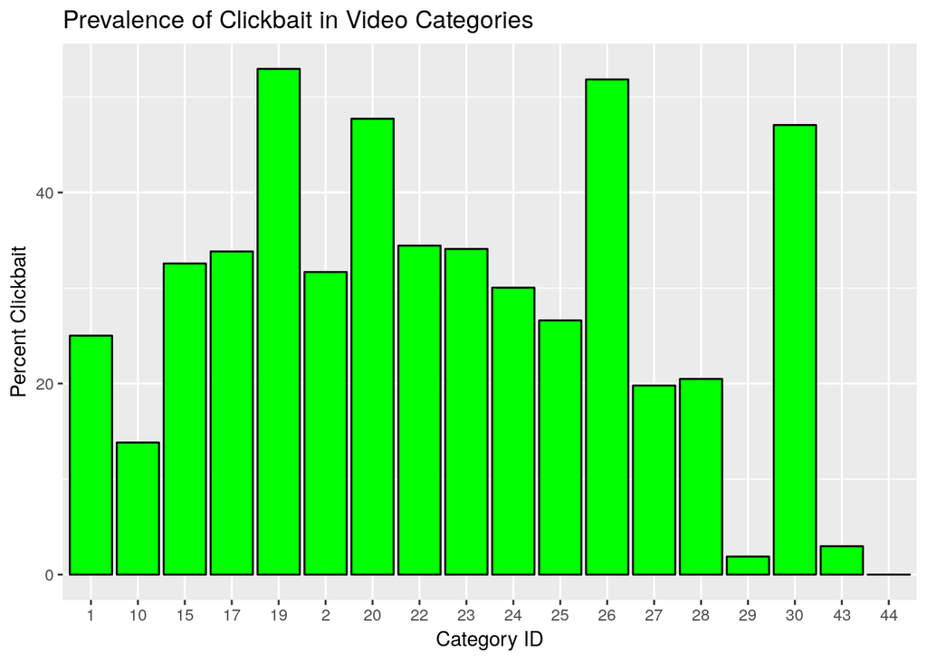

```r
# overall
clickbait_cats %>%
  dplyr::group_by(category_id) %>%
  dplyr::summarize(n = sum(n),
            n_clickbait = sum(n_clickbait),
            p_clickbait = n_clickbait / n) %>%
  ggplot(aes(x = category_id, y = 100*p_clickbait)) +
  geom_col(color = "black", fill = "green") +
  xlab("Category ID") +
  ylab("Percent Clickbait") +
  ggtitle("Prevalence of Clickbait in Video Categories")
```

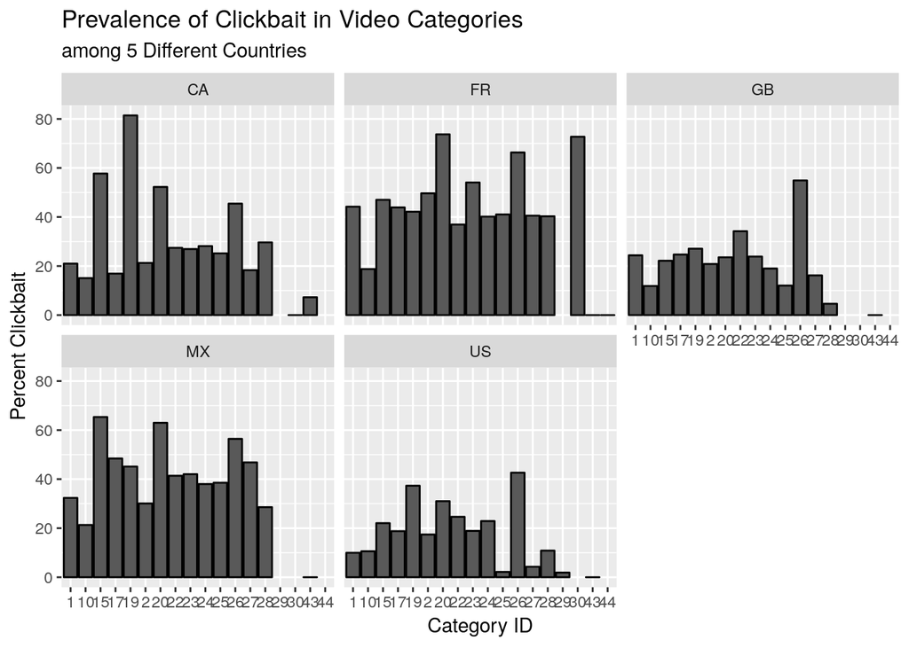

```r
# compare categories within each country
# fill = country is breaking
ggplot(clickbait_cats, aes(x = category_id, y = 100*p_clickbait)) +
  geom_col(color = "black") +
  facet_wrap(~country) +
  xlab("Category ID") +
  ylab("Percent Clickbait") +
  ggtitle("Prevalence of Clickbait in Video Categories",
          "among 5 Different Countries")
```

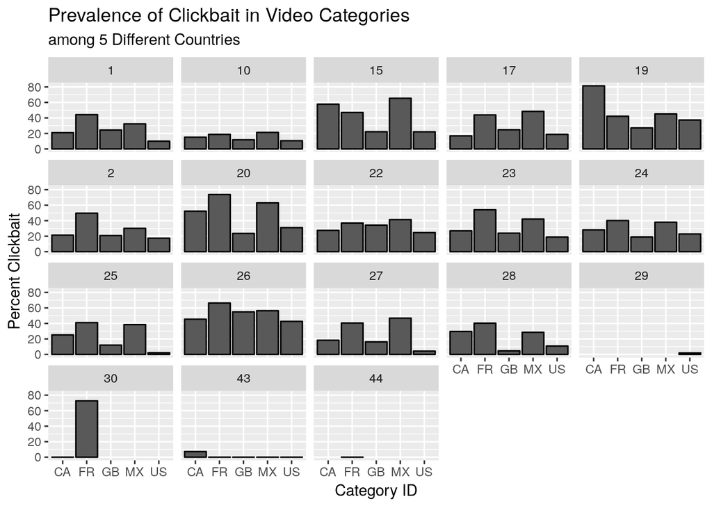

```r
# compare countries within each category
# fill = country is breaking
ggplot(clickbait_cats, aes(x = country, y = 100*p_clickbait)) +
  geom_col(color = "black") +
  facet_wrap(~category_id) +
  xlab("Category ID") +
  ylab("Percent Clickbait") +
  ggtitle("Prevalence of Clickbait in Video Categories",
          "among 5 Different Countries")
```

In most video categories, France and Mexico have clickbait videos more frequently. The margin for this differs across categories, and it varies across categories whether France or Mexico has a higher clickbait frequency. In some categories, Canada has a higher frequency of clickbait as well.

### 7

> How frequently are the comments disabled on trending videos?

```r
cd_sum = alladem %>%
  dplyr::group_by(comments_disabled) %>%
  dplyr::summarize(n = n(),
            views = sum(views),
            avg_views = views / n)
cd_sum
```

```
## # A tibble: 2 x 4
##   comments_disabled      n        views avg_views
##   <lgl>              <int>        <dbl>     <dbl>
## 1 FALSE             277702 446688320035  1608517.
## 2 TRUE                6143   7276740274  1184558.
```

#### Hypothesis tests for difference in likes/views for comments disabled and enabled

```r
LV_test(alladem, type = "comments")
```

```
## # A tibble: 1 x 3
##   enabled_LV_greater z_score p_value
##   <lgl>                <dbl>   <dbl>
## 1 TRUE                  10.2       0
```

```r
DV_test(alladem, type = "comments")
```

```
## # A tibble: 1 x 3
##   enabled_DV_greater z_score p_value
##   <lgl>                <dbl>   <dbl>
## 1 TRUE                  1.02   0.153
```

For the test for a difference in the proportion of likes/view for videos with comments enabled vs. videos with comments disabled, our p-value is approximately 0, which is highly statistically significant. We therefore have very convincing evidence that the proportion of likes/view is higher for videos with comments enabled than for videos with comments disabled.

For the test for a difference in the proportion of dislikes/view for videos with comments enabled vs. videos with comments disabled, our p-value is 0.153, which is not statistically significant. We therefore do not have convincing evidence of a difference in the proportion of dislikes/view for videos with comments enabled vs. videos with comments disabled.

### 8

## do the same channels trend in each country? ( find top 10 trending channels separately for each country )

```r
## add country column to each
ca_data =  ca_data %>%
  mutate(country = case_when(category_id <= 44 ~ 'CA'))
fr_data =  fr_data %>%
  mutate(country = case_when(category_id <= 44 ~ 'FR'))
gb_data =  gb_data %>%
  mutate(country = case_when(category_id <= 44 ~ 'GB'))
in_data =  in_data %>%
  mutate(country = case_when(category_id <= 44 ~ 'IN'))
jp_data =  jp_data %>%
  mutate(country = case_when(category_id <= 44 ~ 'JP'))
mx_data =  mx_data %>%
  mutate(country = case_when(category_id <= 44 ~ 'MX'))
ru_data =  ru_data %>%
  mutate(country = case_when(category_id <= 44 ~ 'RU'))
us_data =  us_data %>%
  mutate(country = case_when(category_id <= 44 ~ 'US'))
```

```r
## Canada
ca = ca_data %>%
  select(channel_title, country, category_title, views) %>%
  rename(Channel_Title = channel_title,
         Country = country,
         Category = category_title,
         Views = views) %>%
  drop_na() %>%
  group_by(Channel_Title) %>%
  summarize(Views = sum(Views)) %>%
  arrange(desc(Views)) %>%
  top_n(n=10)
## France
fr = fr_data %>%
  select(channel_title, country, category_title, views) %>%
  rename(Channel_Title = channel_title,
         Country = country,
         Category = category_title,
         Views = views) %>%
  drop_na() %>%
  group_by(Channel_Title) %>%
  summarize(Views = sum(Views)) %>%
  arrange(desc(Views)) %>%
  top_n(n=10)
## Great Britain
gb = gb_data %>%
  select(channel_title, country, category_title, views) %>%
  rename(Channel_Title = channel_title,
         Country = country,
         Category = category_title,
         Views = views) %>%
  drop_na() %>%
  group_by(Channel_Title) %>%
  summarize(Views = sum(Views)) %>%
  arrange(desc(Views)) %>%
  top_n(n=10)
## India
in1 = in_data %>%
  select(channel_title, country, category_title, views) %>%
  rename(Channel_Title = channel_title,
         Country = country,
         Category = category_title,
         Views = views) %>%
  drop_na() %>%
  group_by(Channel_Title) %>%
  summarize(Views = sum(Views)) %>%
  arrange(desc(Views)) %>%
  top_n(n=10)
## Japan
jp = jp_data %>%
  select(channel_title, country, category_title, views) %>%
  rename(Channel_Title = channel_title,
         Country = country,
         Category = category_title,
         Views = views) %>%
  drop_na() %>%
  group_by(Channel_Title) %>%
  summarize(Views = sum(Views)) %>%
  arrange(desc(Views)) %>%
  top_n(n=10)
## Mexico
mx = mx_data %>%
  select(channel_title, country, category_title, views) %>%
  rename(Channel_Title = channel_title,
         Country = country,
         Category = category_title,
         Views = views) %>%
  drop_na() %>%
  group_by(Channel_Title) %>%
  summarize(Views = sum(Views)) %>%
  arrange(desc(Views)) %>%
  top_n(n=10)
## Russia
ru = ru_data %>%
  select(channel_title, country, category_title, views) %>%
  rename(Channel_Title = channel_title,
         Country = country,
         Category = category_title,
         Views = views) %>%
  drop_na() %>%
  group_by(Channel_Title) %>%
  summarize(Views = sum(Views)) %>%
  arrange(desc(Views)) %>%
  top_n(n=10)
## USA
us = us_data %>%
  select(channel_title, country, category_title, views) %>%
  rename(Channel_Title = channel_title,
         Country = country,
         Category = category_title,
         Views = views) %>%
  drop_na() %>%
  group_by(Channel_Title) %>%
  summarize(Views = sum(Views)) %>%
  arrange(desc(Views)) %>%
  top_n(n=10)
```

### 9

> Do the same categories trend in each country? (find top 10 trending categories separately for each country)

```r
## Canada
ca2 = ca_data %>%
  select(country, category_title, views) %>%
  rename(Country = country,
         Category = category_title,
         Views = views) %>%
  drop_na() %>%
  group_by(Category) %>%
  summarize(Views = sum(Views)) %>%
  arrange(desc(Views)) %>%
  top_n(n=10)
## France
fr2 = fr_data %>%
  select(country, category_title, views) %>%
  rename(Country = country,
         Category = category_title,
         Views = views) %>%
  drop_na() %>%
  group_by(Category) %>%
  summarize(Views = sum(Views)) %>%
  arrange(desc(Views)) %>%
  top_n(n=10)
## Great Britain
gb2 = gb_data %>%
  select(country, category_title, views) %>%
  rename(Country = country,
         Category = category_title,
         Views = views) %>%
  drop_na() %>%
  group_by(Category) %>%
  summarize(Views = sum(Views)) %>%
  arrange(desc(Views)) %>%
  top_n(n=10)
## India
in2 = in_data %>%
  select(country, category_title, views) %>%
  rename(Country = country,
         Category = category_title,
         Views = views) %>%
  drop_na() %>%
  group_by(Category) %>%
  summarize(Views = sum(Views)) %>%
  arrange(desc(Views)) %>%
  top_n(n=10)
## Japan
jp2 = jp_data %>%
  select(country, category_title, views) %>%
  rename(Country = country,
         Category = category_title,
         Views = views) %>%
  drop_na() %>%
  group_by(Category) %>%
  summarize(Views = sum(Views)) %>%
  arrange(desc(Views)) %>%
  top_n(n=10)
## Mexico
mx2 = mx_data %>%
  select(country, category_title, views) %>%
  rename(Country = country,
         Category = category_title,
         Views = views) %>%
  drop_na() %>%
  group_by(Category) %>%
  summarize(Views = sum(Views)) %>%
  arrange(desc(Views)) %>%
  top_n(n=10)
## Russia
ru2 = ru_data %>%
  select(country, category_title, views) %>%
  rename(Country = country,
         Category = category_title,
         Views = views) %>%
  drop_na() %>%
  group_by(Category) %>%
  summarize(Views = sum(Views)) %>%
  arrange(desc(Views)) %>%
  top_n(n=10)
## USA
us2 = us_data %>%
  select(country, category_title, views) %>%
  rename(Country = country,
         Category = category_title,
         Views = views) %>%
  drop_na() %>%
  group_by(Category) %>%
  summarize(Views = sum(Views)) %>%
  arrange(desc(Views)) %>%
  top_n(n=10)
```

### 10

> Does a particular time of year also have particular tags?

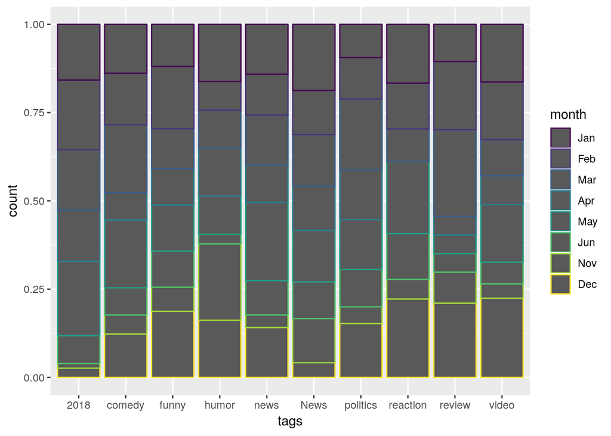

```r
split_data = function(df) {
  cSplit(df, "tags", sep="|") %>%
    select(video_id, trending_date, starts_with("tags")) %>%
    mutate(trending_date = ydm(trending_date)) %>%
    gather(starts_with("tags"), key = "num", value = "tags") %>%
    drop_na()
}

tidy_data = function(df) {
  return( split_data(df) %>%
              group_by(video_id) %>%
              distinct(num, .keep_all = TRUE)
        )
}

top_10 = function (df) {
  df = df %>%
    filter(!(tags == "[none]")) %>%
    mutate(month = month(trending_date, label = TRUE))

  temp = ddply(df,~tags,summarise,number_of_distinct=length(unique(video_id))) %>%
    arrange(desc(number_of_distinct)) %>%
    top_n(10, wt=number_of_distinct)

  df = df[unlist(sapply(1:NROW(filter), function(i)
    which(df$tags == temp$tags))),]

  return(df)
}

cumulative = function(df) {
  df = tidy_data(df)
  df = top_10(df)
  return(df)
}

plot = function(df) {
  df %>%
  mutate(month = month(trending_date, label = TRUE)) %>%
  ggplot(aes(x = tags, colour = month)) +
     geom_bar(position = "fill")
}

ca_data = cumulative(ca_data)
plot(ca_data)
```

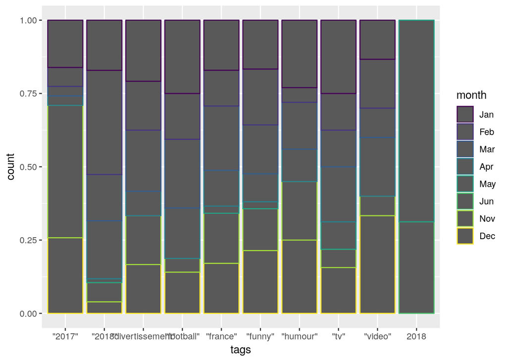

```r
fr_data = cumulative(fr_data)
plot(fr_data)
```

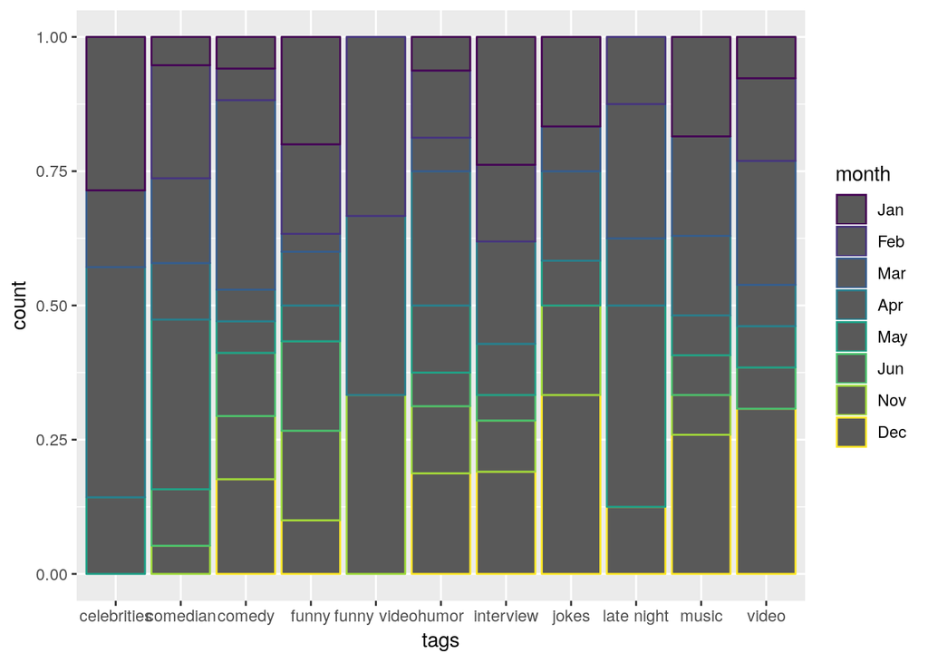

```r
gb_data = cumulative(gb_data)
plot(gb_data)
```

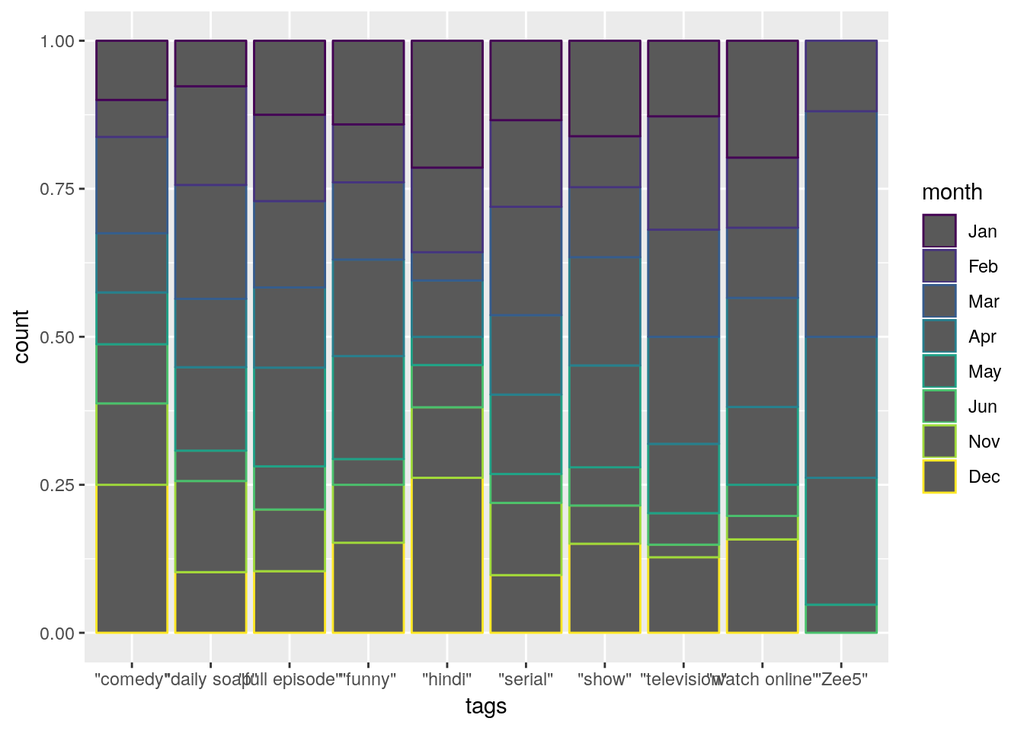

```r
in_data = cumulative(in_data)
plot(in_data)
```

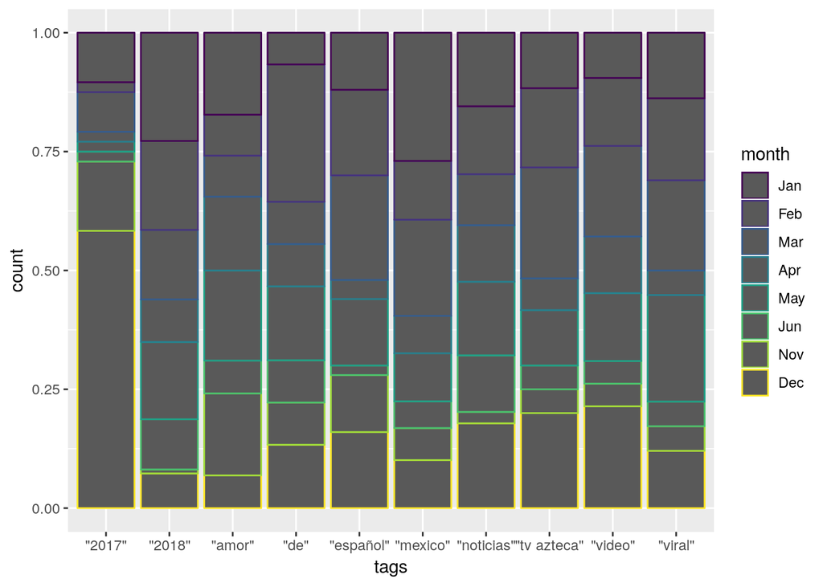

```r
mx_data = cumulative(mx_data)
plot(mx_data)
```

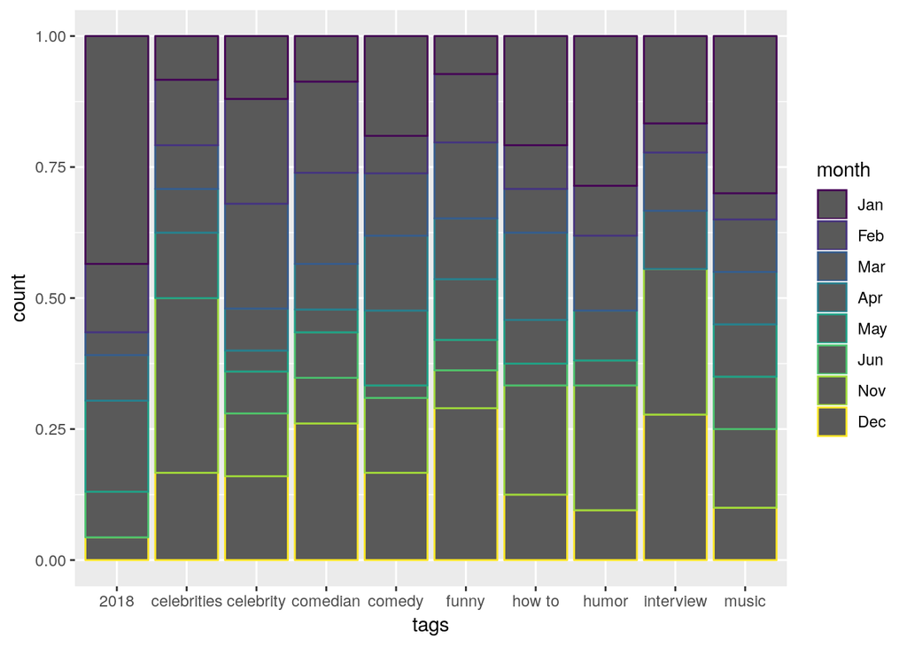

```r
us_data = cumulative(us_data)
plot(us_data)
```

### 11

> For trending videos do they have any patterns in tags across countries?

```r
common_tags = function(df1, df1_name, df2, df2_name){
  df1_temp = df1 %>%
    ddply(~tags,summarise,number_of_occurence=length(unique(video_id)))
  df2_temp = df2 %>%
    ddply(~tags,summarise,number_of_occurence=length(unique(video_id)))
  return(inner_join(df1_temp, df2_temp, by="tags", suffix = c(df1_name, df2_name)))
}

in_fr_join = common_tags(fr_data, "-fr", in_data, "-in")
in_fr_join
```

```
##      tags number_of_occurence-fr number_of_occurence-in
## 1 "funny"                     42                     92
```

```r
ca_us_join = common_tags(ca_data, "-ca", us_data, "-us" )
ca_us_join
```

```
##     tags number_of_occurence-ca number_of_occurence-us
## 1   2018                     76                     23
## 2 comedy                    130                     42
## 3  funny                    176                     69
## 4  humor                     37                     21
```

```r
gb_mx_join = common_tags(gb_data, "-gb", mx_data, "-mx")
gb_mx_join
```

```
## [1] tags                   number_of_occurence-gb number_of_occurence-mx
## <0 rows> (or 0-length row.names)
```

## Discussion

For future analysis, it could be interesting to examine data on the number of accounts that liked a video and the number of accounts that viewed a video as a potentially more accurate way of determining whether or not a video is well received. This method would eliminate many views from a video, which are those without an account logged in, but it would eliminate the confounding variable of how many times one person views a video, since they can view it many times but only like it one time. This data could be difficult to get, however. Another direction to go when examining this data further could be to analyze video descriptions and see if those have any effect on how much people like a video. This would be difficult because the descriptions tend to be long strings that are hard to analyze well.